# 20211226_Histo_CorrelationPlot_SK_V003

#### This notebook is created on 26 of Dec 2021 to plot correlation between different scorers.

It is corrected on 20th of Jan, 2022.

They had a first round of scoring with Sandra, Martin, Sinem, Oscar, and Deniz on only two sample group of Control and MV+LPS. The second round was the same people but they scored all 5 sample groups. And the point is these five people scored the images in 0-8 range. However, the gold-standard paper that Iran compares their work to that is in the range of 0-2. So, Iran made the transformation of these scores from 0-8 to 0-2. Then, They had new scorers called Isabel, Pablo, Pieter, Laura, Nika, och Darcy. They scored the same images in the range of 0-2 originally. Then only three of these people (Isabel, Nika, and Darcy) repeat their scoring in the range of 0-8 one or two month later. Iran wanted me to plot the correlation between the scores of first 5 people with the second 6 people where both scores are in range of 0-2 (the scores of first group transformed to 0-2 and the second group of six people were originally in the range of 0-2.). And also the agreement between the scores of three people (Isable, Nika, and Darcy) which is done with one or two month time in between and the first time was in range of 0-2 and the second time in range of 0-8.

## Summary of the scorers, level of expertise, and the range of scores

```python
import pandas as pd
Scores = {}
Scores['People'] = ['Martin', 'Sandra', 'Sinem', 'Oscar', 'Deniz', 'Isabel','Pablo','Pieter','Laura','Nika','Darcy']
Scores['Expertise level'] = ['Intermediate', 'Intermediate', 'Novice', 'Expert', 'Expert', 'Intermediate','Novice','Novice','Novice','Expert','Expert']
Scores['Oringinal range of scoring']=['0-8','0-8','0-8','0-8','0-8','0-2 and 0-8','0-2','0-2','0-2','0-2 and 0-8','0-2 and 0-8']
Scores['Number of scoring times']=['1','1','1','1','1','2','1','1','1','2','2']


df_s  = pd.DataFrame.from_dict(Scores)
df_s
```

|  | People | Expertise level | Oringinal range of scoring | Number of scoring times |
| --- | --- | --- | --- | --- |
| 0 | Martin | Intermediate | 0-8 | 1 |
| 1 | Sandra | Intermediate | 0-8 | 1 |
| 2 | Sinem | Novice | 0-8 | 1 |
| 3 | Oscar | Expert | 0-8 | 1 |
| 4 | Deniz | Expert | 0-8 | 1 |
| 5 | Isabel | Intermediate | 0-2 and 0-8 | 2 |
| 6 | Pablo | Novice | 0-2 | 1 |
| 7 | Pieter | Novice | 0-2 | 1 |
| 8 | Laura | Novice | 0-2 | 1 |
| 9 | Nika | Expert | 0-2 and 0-8 | 2 |
| 10 | Darcy | Expert | 0-2 and 0-8 | 2 |

We have three sets of scores from 5, 6, and 3 people. I plotted the correlation between the first vs second set, and the three of second set vs third group (same people)

#### 20210311_Scores_without23_Histology_IA.xlsx

I removed the slide 23 from this data which was shared with us 11th of March 2021

#### 20211217_Scores_Histology_IA.xlsx

Which is the scores of Martin, Sandra, Sinem, Oscar, and Deniz on all sample groups. The file is shared with us on 17th of Dec, 2021 and it is originally called

#### messurement plus the transformation to the range of the standard version .xlsx

#### 20211217_Scores_Histology_IA_third.xlsx

Which has three sheets.

1. The first sheet called 'STDS 0-2' and It is the scores of 6 people in the range of 0-2 and features a-e.
2. The second sheet called 'transformation to the same range' and it is the scores of first 5 people and the scores should be transformed to 0-2.
3. The third sheet is called 'repeat 0-8' and should be transformed to 0-2 to be able to compare to the other scores.

The file is shared with us on 17th of Dec, 2021 and it is originally called

### First scores extracted from 20210311_Scores_without23_Histology_IA.xlsx

```python
import pandas as pd
df = pd.read_excel('excel_data/20210311_Scores_without23_Histology_IA.xlsx',sheet_name=1,na_values=None, keep_default_na=False, na_filter=True)



import re
import numpy as np

total_score = {}
a_score = {}
b_score = {}
c_score = {}
d_score = {}
e_score = {}
f_score = {}
g_score = {}

# Make a regular expression
# for identifying a digit
regex = '^[0-9]+$'



from pandas.core.indexes import numeric

for tr in range(len(df['Unnamed: 1'])):
  if(re.search(regex, str(df['Unnamed: 1'][tr]))):
    total_score[df['Unnamed: 1'][tr]] = list(df.iloc[tr+8, 2:])
    a_score[df['Unnamed: 1'][tr]] = list(df.iloc[tr+1, 2:])
    b_score[df['Unnamed: 1'][tr]] = list(df.iloc[tr+2, 2:])
    c_score[df['Unnamed: 1'][tr]] = list(df.iloc[tr+3, 2:])
    d_score[df['Unnamed: 1'][tr]] = list(df.iloc[tr+4, 2:])
    e_score[df['Unnamed: 1'][tr]] = list(df.iloc[tr+5, 2:])
    f_score[df['Unnamed: 1'][tr]] = list(df.iloc[tr+6, 2:])
    g_score[df['Unnamed: 1'][tr]] = list(df.iloc[tr+7, 2:])

print(len(a_score))

data_total_col =['Sandra Intermediate','Martin Intermediate','Sinem Novice','Oscar Expert','Deniz Expert']
data_total_index = total_score.keys()

df_total = pd.DataFrame(total_score,index = data_total_index, columns=data_total_col)
df_a = pd.DataFrame(a_score,index = data_total_index, columns=data_total_col,dtype=int)
df_b = pd.DataFrame(b_score,index = data_total_index, columns=data_total_col)
df_c = pd.DataFrame(c_score,index = data_total_index, columns=data_total_col)
df_d = pd.DataFrame(d_score,index = data_total_index, columns=data_total_col)
df_e = pd.DataFrame(e_score,index = data_total_index, columns=data_total_col)
df_f = pd.DataFrame(f_score,index = data_total_index, columns=data_total_col)
df_g = pd.DataFrame(g_score,index = data_total_index, columns=data_total_col)



data_total ={}


for k in total_score.keys():
  df_total.loc[k,:]=total_score[k]
  df_a.loc[k,:]=a_score[k]
  df_b.loc[k,:]=b_score[k]
  df_c.loc[k,:]=c_score[k]
  df_d.loc[k,:]=d_score[k]
  df_e.loc[k,:]=e_score[k]
  df_f.loc[k,:]=f_score[k]
  df_g.loc[k,:]=g_score[k]



df_a.index.name = 'Indxa'
df_a_sorted = df_a.sort_values('Indxa')

df_a


df_b.index.name = 'Indxb'
df_b_sorted = df_b.sort_values('Indxb')

df_c.index.name = 'Indxc'
df_c_sorted = df_c.sort_values('Indxc')


df_d.index.name = 'Indxd'
df_d_sorted = df_d.sort_values('Indxd')

df_e.index.name = 'Indxe'
df_e_sorted = df_e.sort_values('Indxe')

df_f.index.name = 'Indxf'
df_f_sorted = df_f.sort_values('Indxf')

df_g.index.name = 'Indxg'
df_g_sorted = df_g.sort_values('Indxg')

df_total.index.name = 'Indxtotal'
df_total_sorted = df_total.sort_values('Indxtotal')


df_total_sorted
```

```
44
```

| Indxtotal | Sandra Intermediate | Martin Intermediate | Sinem Novice | Oscar Expert | Deniz Expert |
| --- | --- | --- | --- | --- | --- |
| 1 | 42 | 43 | 17 | 37 | 42 |
| 2 | 23 | 38 | 13 | 24 | 25 |
| 3 | 8 | 7 | 1 | 8 | 4 |
| 4 | 2 | 13 | 2 | 15 | 7 |
| 5 | 25 | 31 | 9 | 20 | 21 |
| 6 | 43 | 44 | 21 | 35 | 41 |
| 7 | 33 | 42 | 32 | 36 | 42 |
| 9 | 35 | 43 | 22 | 23 | 24 |
| 10 | 3 | 12 | 4 | 11 | 6 |
| 11 | 1 | 9 | 1 | 4 | 5 |
| 12 | 3 | 18 | 2 | 10 | 9 |
| 13 | 5 | 22 | 2 | 13 | 13 |
| 14 | 2 | 17 | 5 | 8 | 6 |
| 15 | 3 | 7 | 8 | 11 | 18 |
| 16 | 2 | 9 | 10 | 2 | 5 |
| 17 | 2 | 14 | 6 | 8 | 7 |
| 18 | 3 | 11 | 0 | 5 | 6 |
| 19 | 2 | 9 | 4 | 7 | 15 |
| 20 | 10 | 12 | 9 | 18 | 16 |
| 21 | 3 | 15 | 4 | 9 | 10 |
| 26 | 31 | 38 | 35 | 30 | 46 |
| 27 | 0 | 12 | 10 | 2 | 2 |
| 28 | 2 | 12 | 1 | 5 | 5 |
| 29 | 7 | 20 | 1 | 16 | 19 |
| 30 | 13 | 25 | 6 | 22 | 17 |
| 31 | 3 | 17 | 1 | 14 | 14 |
| 32 | 5 | 27 | 4 | 13 | 14 |
| 33 | 0 | 8 | 0 | 2 | 5 |
| 34 | 2 | 14 | 2 | 2 | 6 |
| 35 | 23 | 37 | 11 | 20 | 37 |
| 36 | 20 | 36 | 11 | 14 | 17 |
| 37 | 28 | 43 | 25 | 26 | 40 |
| 38 | 19 | 40 | 9 | 28 | 36 |
| 39 | 26 | 36 | 40 | 29 | 31 |
| 40 | 2 | 12 | 9 | 19 | 9 |
| 41 | 8 | 24 | 9 | 15 | 11 |
| 42 | 30 | 37 | 25 | 19 | 32 |
| 43 | 13 | 26 | 10 | 21 | 13 |
| 44 | 39 | 42 | 41 | 24 | 38 |
| 45 | 48 | 49 | 48 | 37 | 47 |
| 46 | 2 | 21 | 2 | 8 | 2 |
| 47 | 0 | 2 | 5 | 2 | 1 |
| 48 | 13 | 30 | 6 | 15 | 18 |
| 49 | 3 | 5 | 4 | 3 | 0 |

### Plotting the correlation of the first group of 5 people with themselves over all sample groups and separately on each sample group

```python
import pandas as pd
import matplotlib.pyplot as plt
import seaborn as sn


df_orig = pd.read_excel('excel_data/20210311_Scores_without23_Histology_IA.xlsx',sheet_name=0,na_values=None, keep_default_na=False, na_filter=True)

df_orig
```

|  | PDF/ EXCEL correspodent Data | (sanned slide) Sample Name | Group | Sandra Intermediate | Martin Intermediate | Sinem novice | Oscar Expert | Deniz Expert | min | max | Median | Average | STDEV.P |
| --- | --- | --- | --- | --- | --- | --- | --- | --- | --- | --- | --- | --- | --- |
| 0 | 10 | 9 | control | 3 | 12 | 4 | 11 | 6 | 3 | 12 | 6 | 7.2 | 3.655133 |
| 1 | 15 | 14 | Control | 3 | 7 | 8 | 11 | 18 | 3 | 18 | 8 | 9.4 | 5.003998 |
| 2 | 16 | 15 | Control | 2 | 9 | 10 | 2 | 5 | 2 | 10 | 5 | 5.6 | 3.382307 |
| 3 | 17 | 16 | Control | 2 | 14 | 6 | 8 | 7 | 2 | 14 | 7 | 7.4 | 3.878144 |
| 4 | 18 | 17 | Control | 3 | 11 | 0 | 5 | 6 | 0 | 11 | 5 | 5.0 | 3.633180 |
| 5 | 19 | 18 | Control | 2 | 9 | 4 | 7 | 15 | 2 | 15 | 7 | 7.4 | 4.498889 |
| 6 | 20 | 19 | Control | 10 | 12 | 9 | 18 | 16 | 9 | 18 | 12 | 13.0 | 3.464102 |
| 7 | 21 | 20 | Control | 3 | 15 | 4 | 9 | 10 | 3 | 15 | 9 | 8.2 | 4.354308 |
| 8 | 23 | 28 | Control | 0 | 10 | 1 | 9 | 7 | 0 | 10 | 7 | 5.4 | 4.127953 |
| 9 | 27 | 26 | Control | 0 | 12 | 10 | 2 | 2 | 0 | 12 | 2 | 5.2 | 4.833218 |
| 10 | 46 | 46 | Control | 2 | 21 | 2 | 8 | 2 | 2 | 21 | 2 | 7.0 | 7.375636 |
| 11 | 47 | 47 | Control | 0 | 2 | 5 | 2 | 1 | 0 | 5 | 2 | 2.0 | 1.673320 |
| 12 | 35 | 35 | MV+LPS | 23 | 37 | 11 | 20 | 37 | 11 | 37 | 23 | 25.6 | 10.111380 |
| 13 | 36 | 36 | MV+LPS | 20 | 36 | 11 | 14 | 17 | 11 | 36 | 17 | 19.6 | 8.731552 |
| 14 | 41 | 41 | MV+LPS | 8 | 24 | 9 | 15 | 11 | 8 | 24 | 11 | 13.4 | 5.817216 |
| 15 | 42 | 42 | MV+LPS | 30 | 37 | 25 | 19 | 32 | 19 | 37 | 30 | 28.6 | 6.151423 |
| 16 | 43 | 43 | MV+LPS | 13 | 26 | 10 | 21 | 13 | 10 | 26 | 13 | 16.6 | 5.953150 |
| 17 | 44 | 44 | MV+LPS | 39 | 42 | 41 | 24 | 38 | 24 | 42 | 39 | 36.8 | 6.554388 |
| 18 | 45 | 45 | MV+LPS | 48 | 49 | 48 | 37 | 47 | 37 | 49 | 48 | 45.8 | 4.445222 |
| 19 | 1 | 1 | ECMO + LPS | 42 | 43 | 17 | 37 | 42 | 17 | 43 | 42 | 36.2 | 9.826495 |
| 20 | 2 | 2 | ECMO + LPS | 23 | 38 | 13 | 24 | 25 | 13 | 38 | 24 | 24.6 | 7.964923 |
| 21 | 3 | 3 | MV | 8 | 7 | 1 | 8 | 4 | 1 | 8 | 7 | 5.6 | 2.727636 |
| 22 | 4 | 4 | ECMO + LPS | 2 | 13 | 2 | 15 | 7 | 2 | 15 | 7 | 7.8 | 5.418487 |
| 23 | 5 | 5 | ECMO + LPS | 25 | 31 | 9 | 20 | 21 | 9 | 31 | 21 | 21.2 | 7.222188 |
| 24 | 6 | 6 | ECMO + LPS | 43 | 44 | 21 | 31 | 41 | 21 | 44 | 41 | 36.0 | 8.809086 |
| 25 | 7 | 7 | ECMO + LPS | 33 | 42 | 32 | 36 | 42 | 32 | 42 | 36 | 37.0 | 4.289522 |
| 26 | 9 | 8 | ECMO + LPS | 35 | 43 | 22 | 23 | 24 | 22 | 43 | 24 | 29.4 | 8.260751 |
| 27 | 11 | 10 | MV | 1 | 9 | 1 | 4 | 5 | 1 | 9 | 4 | 4.0 | 2.966479 |
| 28 | 12 | 11 | ECMO | 3 | 18 | 2 | 10 | 9 | 2 | 18 | 9 | 8.4 | 5.748043 |
| 29 | 13 | 12 | ECMO | 5 | 22 | 2 | 13 | 13 | 2 | 22 | 13 | 11.0 | 7.014271 |
| 30 | 14 | 13 | MV | 2 | 17 | 5 | 8 | 6 | 2 | 17 | 6 | 7.6 | 5.083306 |
| 31 | 29 | 29 | ECMO | 7 | 20 | 1 | 16 | 19 | 1 | 20 | 16 | 12.6 | 7.391887 |
| 32 | 30 | 30 | ECMO | 13 | 25 | 6 | 22 | 17 | 6 | 25 | 17 | 16.6 | 6.711185 |
| 33 | 31 | 31 | ECMO | 3 | 17 | 1 | 14 | 14 | 1 | 17 | 14 | 9.8 | 6.493073 |
| 34 | 32 | 32 | ECMO | 5 | 27 | 4 | 13 | 14 | 4 | 27 | 13 | 12.6 | 8.260751 |
| 35 | 33 | 33 | ECMO | 0 | 8 | 0 | 2 | 5 | 0 | 8 | 2 | 3.0 | 3.098387 |
| 36 | 34 | 34 | MV | 2 | 14 | 2 | 2 | 6 | 2 | 14 | 2 | 5.2 | 4.664762 |
| 37 | 37 | 37 | ECMO + LPS | 28 | 43 | 25 | 26 | 40 | 25 | 43 | 28 | 32.4 | 7.552483 |
| 38 | 38 | 38 | ECMO + LPS | 19 | 40 | 9 | 28 | 36 | 9 | 40 | 28 | 26.4 | 11.288933 |
| 39 | 39 | 39 | ECMO | 26 | 36 | 40 | 29 | 31 | 26 | 40 | 31 | 32.4 | 5.003998 |
| 40 | 40 | 40 | ECMO | 2 | 12 | 9 | 19 | 9 | 2 | 19 | 9 | 10.2 | 5.491812 |
| 41 | 48 | 48 | ECMO + LPS | 13 | 30 | 6 | 15 | 18 | 6 | 30 | 15 | 16.4 | 7.863841 |
| 42 | 49 | 49 | ECMO | 3 | 5 | 4 | 3 | 0 | 0 | 5 | 3 | 3.0 | 1.673320 |
| 43 | 26 | 25 | ECMO + LPS | 31 | 38 | 35 | 30 | 46 | 30 | 46 | 35 | 36.0 | 5.761944 |
| 44 | 28 | 28 | MV | 2 | 12 | 1 | 5 | 5 | 1 | 12 | 5 | 5.0 | 3.847077 |

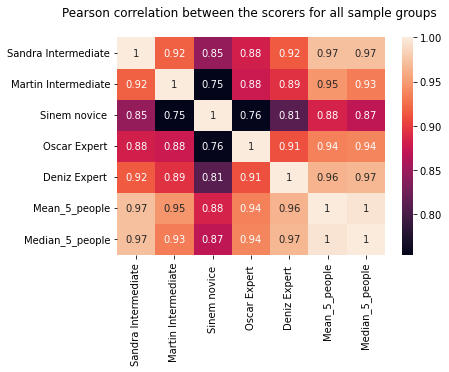

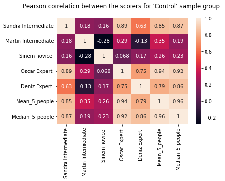

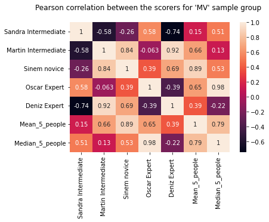

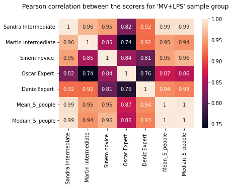

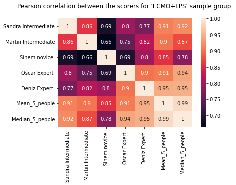

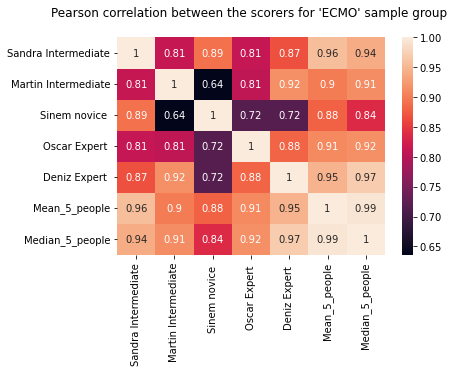

```python
import pandas as pd
import matplotlib.pyplot as plt
import seaborn as sn


df_orig = pd.read_excel('excel_data/20210311_Scores_without23_Histology_IA.xlsx',sheet_name=0,na_values=None, keep_default_na=False, na_filter=True)



df_orig_scores = df_orig.iloc[:,3:8]
mean_col      = df_orig_scores.mean(axis = 1)
df_orig_scores['Mean_5_people'] = mean_col
median_col      = df_orig_scores.median(axis = 1)
df_orig_scores['Median_5_people'] = median_col




cor_orig_mat = df_orig_scores.corr(method='pearson')
hm = sn.heatmap(cor_orig_mat, annot = True)
hm.set(title = "Pearson correlation between the scorers for all sample groups \n")
plt.show()


######################
df_control = df_orig.loc[df_orig['Group ']== 'Control']
df_control_scores = df_control.iloc[:,3:8]

mean_col_control      = df_control_scores.mean(axis = 1)
df_control_scores['Mean_5_people'] = mean_col_control
median_col_control      = df_control_scores.median(axis = 1)
df_control_scores['Median_5_people'] = median_col_control

df_control_scores
cor_control_mat = df_control_scores.corr(method='pearson')
hm = sn.heatmap(cor_control_mat, annot = True)
hm.set(title = "Pearson correlation between the scorers for 'Control' sample group \n")
plt.show()
#######################

df_MV = df_orig.loc[df_orig['Group ']== 'MV']
df_MV_scores = df_MV.iloc[:,3:8]
df_MV_scores




mean_col_MV      = df_MV_scores.mean(axis = 1)
df_MV_scores['Mean_5_people'] = mean_col_MV
median_col_MV      = df_MV_scores.median(axis = 1)
df_MV_scores['Median_5_people'] = median_col_MV


cor_MV_mat = df_MV_scores.corr(method='pearson')
hm = sn.heatmap(cor_MV_mat, annot = True)
hm.set(title = "Pearson correlation between the scorers for 'MV' sample group \n")
plt.show()
###################################


df_MV_LPS = df_orig.loc[df_orig['Group ']== 'MV+LPS']
df_MV_LPS_scores = df_MV_LPS.iloc[:,3:8]
df_MV_LPS_scores

mean_col_MV_LPS     = df_MV_LPS_scores.mean(axis = 1)
df_MV_LPS_scores['Mean_5_people'] = mean_col_MV_LPS
median_col_MV_LPS      = df_MV_LPS_scores.median(axis = 1)
df_MV_LPS_scores['Median_5_people'] = median_col_MV_LPS

cor_MV_LPS_mat = df_MV_LPS_scores.corr(method='pearson')
hm = sn.heatmap(cor_MV_LPS_mat, annot = True)
hm.set(title = "Pearson correlation between the scorers for 'MV+LPS' sample group \n")
plt.show()


df_ECMO_LPS = df_orig.loc[df_orig['Group ']== 'ECMO + LPS']
df_ECMO_LPS_scores = df_ECMO_LPS.iloc[:,3:8]
df_ECMO_LPS_scores

mean_col_ECMO_LPS     = df_ECMO_LPS_scores.mean(axis = 1)
df_ECMO_LPS_scores['Mean_5_people'] = mean_col_ECMO_LPS
median_col_ECMO_LPS      = df_ECMO_LPS_scores.median(axis = 1)
df_ECMO_LPS_scores['Median_5_people'] = median_col_ECMO_LPS


cor_ECMO_LPS_mat = df_ECMO_LPS_scores.corr(method='pearson')
hm = sn.heatmap(cor_ECMO_LPS_mat, annot = True)
hm.set(title = "Pearson correlation between the scorers for 'ECMO+LPS' sample group \n")
plt.show()

df_ECMO = df_orig.loc[df_orig['Group ']== 'ECMO']
df_ECMO_scores = df_ECMO.iloc[:,3:8]
df_ECMO_scores

mean_col_ECMO     = df_ECMO_scores.mean(axis = 1)
df_ECMO_scores['Mean_5_people'] = mean_col_ECMO
median_col_ECMO      = df_ECMO_scores.median(axis = 1)
df_ECMO_scores['Median_5_people'] = median_col_ECMO

cor_ECMO_mat = df_ECMO_scores.corr(method='pearson')
hm = sn.heatmap(cor_ECMO_mat, annot = True)
hm.set(title = "Pearson correlation between the scorers for 'ECMO' sample group \n")
plt.show()
```

### this section is only for plotting the different characteristics of the scores for the first group of 5 people

The min, max, std, and median of the data is plotted over all sample groups and for each sample group separately

### Data characteristics

#### Here, I have changed the mean to median according what Iran said based on this paper.

https://www.ncbi.nlm.nih.gov/pmc/articles/PMC3795863/

Each field scored and a mean (i.e. average) score assigned for the whole tissue of that animal. The problem with this approach is that the mean represents a measure of central tendency that is only appropriate for interval and ratio data. For ordinal data, the median is the most appropriate measure for central tendency. This statistical axiom is not without some controversy and it is not within the scope of this paper to resolve it.

```
Sandra Intermediate     5.0
Martin Intermediate    20.0
Sinem novice            6.0
Oscar Expert           14.0
Deniz Expert           14.0
dtype: float64
Sandra Intermediate    13.044444
Martin Intermediate    23.088889
Sinem novice           10.844444
Oscar Expert           15.444444
Deniz Expert           17.533333
dtype: float64
Sandra Intermediate    14.137242
Martin Intermediate    13.564362
Sinem novice           12.107390
Oscar Expert           10.089498
Deniz Expert           14.007466
dtype: float64
Sandra Intermediate    0.0
Martin Intermediate    2.0
Sinem novice           0.0
Oscar Expert           2.0
Deniz Expert           0.0
dtype: float64
Sandra Intermediate    48.0
Martin Intermediate    49.0
Sinem novice           48.0
Oscar Expert           37.0
Deniz Expert           47.0
dtype: float64
[2 3 4 5 6]
```

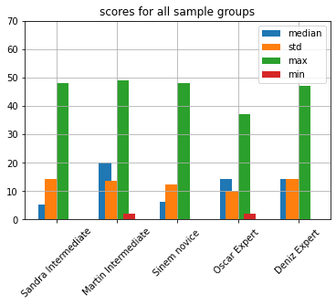

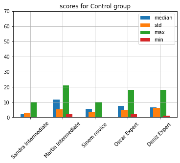

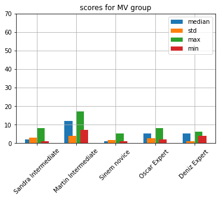

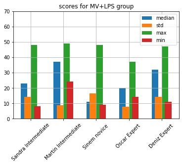

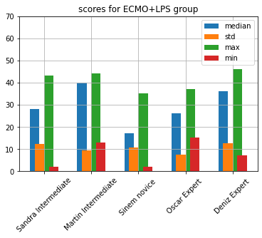

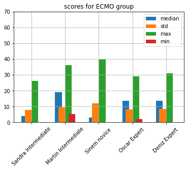

```python
import numpy as np
df_orig_scores
median_all = df_orig_scores.median(axis=0)
median_all.pop('Median_5_people')
median_all.pop('Mean_5_people')
print(median_all)

mean_all = df_orig_scores.mean(axis=0)
mean_all.pop('Median_5_people')
mean_all.pop('Mean_5_people')
print(mean_all)


std_all = df_orig_scores.std(axis = 0)
std_all.pop('Median_5_people')
std_all.pop('Mean_5_people')
print(std_all)

min_all = df_orig_scores.min(axis = 0)
min_all.pop('Median_5_people')
min_all.pop('Mean_5_people')
print(min_all)

max_all = df_orig_scores.max(axis = 0)
max_all.pop('Median_5_people')
max_all.pop('Mean_5_people')
print(max_all)


x = np.array([1,2,3,4,5])
print(x+1)

plt.bar(x-0.2, median_all.values, width = 0.2)
plt.bar(x-0.1, std_all.values, width = 0.2)
plt.bar(x+0.1, max_all.values, width = 0.2)
plt.bar(x + 0.2, min_all.values, width = 0.2)
#plt.bar(x + 0.3, mean_all.values, width = 0.2)
plt.legend(["median", "std", "max", "min"])
plt.title('scores for all sample groups')
plt.xticks(x,median_all.keys(), rotation=45)
plt.grid()
plt.ylim(0,70)
plt.figure()


#############################################
median_control = df_control_scores.median(axis=0)
median_control.pop('Median_5_people')
median_control.pop('Mean_5_people')
std_control = df_control_scores.std(axis = 0)
std_control.pop('Median_5_people')
std_control.pop('Mean_5_people')
min_control = df_control_scores.min(axis = 0)
min_control.pop('Median_5_people')
min_control.pop('Mean_5_people')
max_control = df_control_scores.max(axis = 0)
max_control.pop('Median_5_people')
max_control.pop('Mean_5_people')
mean_control= df_control_scores.mean(axis=0)
mean_control.pop('Median_5_people')
mean_control.pop('Mean_5_people')


plt.bar(x-0.2, median_control.values, width = 0.2)
plt.bar(x-0.1, std_control.values, width = 0.2)
plt.bar(x+0.1, max_control.values, width = 0.2)
plt.bar(x + 0.2, min_control.values, width = 0.2)
#plt.bar(x + 0.3, mean_control.values, width = 0.2)

plt.legend(["median", "std", "max", "min"])
plt.title('scores for Control group')
plt.xticks(x,median_control.keys(), rotation=45)
plt.grid()
plt.ylim(0,70)
plt.figure()
#############################################
#############################################
median_MV = df_MV_scores.median(axis=0)
median_MV.pop('Median_5_people')
median_MV.pop('Mean_5_people')
std_MV = df_MV_scores.std(axis = 0)
std_MV.pop('Median_5_people')
std_MV.pop('Mean_5_people')
min_MV = df_MV_scores.min(axis = 0)
min_MV.pop('Median_5_people')
min_MV.pop('Mean_5_people')
max_MV = df_MV_scores.max(axis = 0)
max_MV.pop('Median_5_people')
max_MV.pop('Mean_5_people')
mean_MV = df_MV_scores.mean(axis=0)
mean_MV.pop('Median_5_people')
mean_MV.pop('Mean_5_people')


plt.bar(x-0.2, median_MV.values, width = 0.2)
plt.bar(x-0.1, std_MV.values, width = 0.2)
plt.bar(x+0.1, max_MV.values, width = 0.2)
plt.bar(x + 0.2, min_MV.values, width = 0.2)
#plt.bar(x + 0.3, mean_MV.values, width = 0.2)

plt.legend(["median", "std", "max", "min"])
plt.title('scores for MV group')
plt.xticks(x,median_MV.keys(), rotation=45)
plt.grid()
plt.ylim(0,70)
plt.figure()
#############################################
median_MV_LPS = df_MV_LPS_scores.median(axis=0)
median_MV_LPS.pop('Median_5_people')
median_MV_LPS.pop('Mean_5_people')
std_MV_LPS = df_MV_LPS_scores.std(axis = 0)
std_MV_LPS.pop('Median_5_people')
std_MV_LPS.pop('Mean_5_people')
min_MV_LPS = df_MV_LPS_scores.min(axis = 0)
min_MV_LPS.pop('Median_5_people')
min_MV_LPS.pop('Mean_5_people')
max_MV_LPS = df_MV_LPS_scores.max(axis = 0)
max_MV_LPS.pop('Median_5_people')
max_MV_LPS.pop('Mean_5_people')
mean_MV_LPS = df_MV_LPS_scores.mean(axis = 0)
mean_MV_LPS.pop('Median_5_people')
mean_MV_LPS.pop('Mean_5_people')

plt.bar(x-0.2, median_MV_LPS.values, width = 0.2)
plt.bar(x-0.1, std_MV_LPS.values, width = 0.2)
plt.bar(x+0.1, max_MV_LPS.values, width = 0.2)
plt.bar(x + 0.2, min_MV_LPS.values, width = 0.2)
#plt.bar(x + 0.2, mean_MV_LPS.values, width = 0.2)


plt.legend(["median", "std", "max", "min"])
plt.title('scores for MV+LPS group')
plt.xticks(x,median_MV_LPS.keys(), rotation=45)
plt.grid()
plt.ylim(0,70)
plt.figure()
############################################
#############################################
median_ECMO_LPS = df_ECMO_LPS_scores.median(axis=0)
median_ECMO_LPS.pop('Median_5_people')
median_ECMO_LPS.pop('Mean_5_people')
std_ECMO_LPS = df_ECMO_LPS_scores.std(axis = 0)
std_ECMO_LPS.pop('Median_5_people')
std_ECMO_LPS.pop('Mean_5_people')
min_ECMO_LPS = df_ECMO_LPS_scores.min(axis = 0)
min_ECMO_LPS.pop('Median_5_people')
min_ECMO_LPS.pop('Mean_5_people')
max_ECMO_LPS = df_ECMO_LPS_scores.max(axis = 0)
max_ECMO_LPS.pop('Median_5_people')
max_ECMO_LPS.pop('Mean_5_people')
mean_ECMO_LPS = df_ECMO_LPS_scores.mean(axis = 0)
mean_ECMO_LPS.pop('Median_5_people')
mean_ECMO_LPS.pop('Mean_5_people')


plt.bar(x-0.2, median_ECMO_LPS.values, width = 0.2)
plt.bar(x-0.1, std_ECMO_LPS.values, width = 0.2)
plt.bar(x+0.1, max_ECMO_LPS.values, width = 0.2)
plt.bar(x + 0.2, min_ECMO_LPS.values, width = 0.2)
#plt.bar(x + 0.2, mean_ECMO_LPS.values, width = 0.2)



plt.legend(["median", "std", "max", "min"])
plt.title('scores for ECMO+LPS group')
plt.xticks(x,median_ECMO_LPS.keys(), rotation=45)
plt.grid()
plt.ylim(0,70)
plt.figure()
############################################
median_ECMO = df_ECMO_scores.median(axis=0)
median_ECMO.pop('Median_5_people')
median_ECMO.pop('Mean_5_people')
std_ECMO  = df_ECMO_scores.std(axis = 0)
std_ECMO.pop('Median_5_people')
std_ECMO.pop('Mean_5_people')
min_ECMO  = df_ECMO_scores.min(axis = 0)
min_ECMO.pop('Median_5_people')
min_ECMO.pop('Mean_5_people')
max_ECMO  = df_ECMO_scores.max(axis = 0)
max_ECMO.pop('Median_5_people')
max_ECMO.pop('Mean_5_people')
mean_ECMO  = df_ECMO_scores.mean(axis = 0)
mean_ECMO.pop('Median_5_people')
mean_ECMO.pop('Mean_5_people')

plt.bar(x-0.2, median_ECMO.values, width = 0.2)
plt.bar(x-0.1, std_ECMO.values, width = 0.2)
plt.bar(x+0.1, max_ECMO.values, width = 0.2)
plt.bar(x + 0.2, min_ECMO.values, width = 0.2)
#plt.bar(x + 0.2, mean_ECMO.values, width = 0.2)

plt.legend(["median", "std", "max", "min"])
plt.title('scores for ECMO group')
plt.xticks(x,median_ECMO.keys(), rotation=45)
plt.grid()
plt.ylim(0,70)
plt.figure()
```

#### This part is for plotting the correlation of first scorers over each feature (a to g)

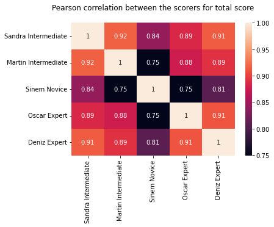

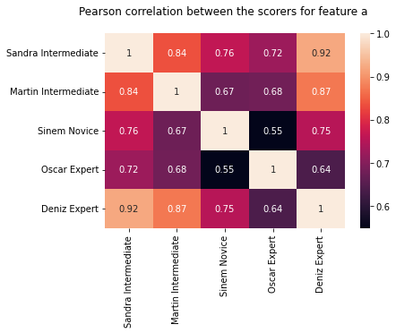

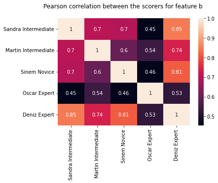

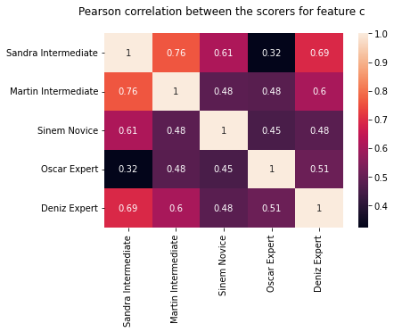

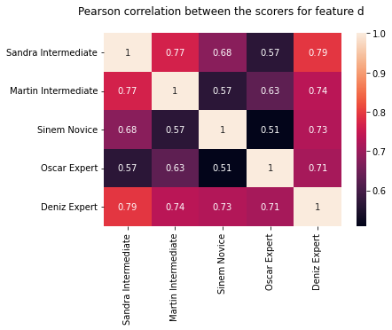

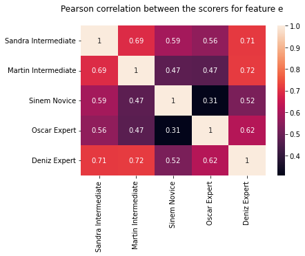

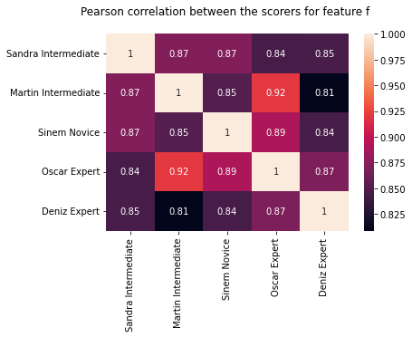

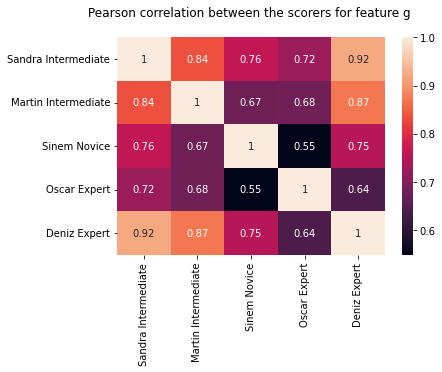

```python
import pandas as pd
import seaborn as sn
import matplotlib.pyplot as plt



cor_total_df = pd.DataFrame(df_total_sorted,index = None,columns = data_total_col,dtype=np.int16)
cor_total_mat = cor_total_df.corr(method='pearson')
hm = sn.heatmap(cor_total_mat, annot = True)
hm.set(title = "Pearson correlation between the scorers for total score\n")
plt.show()


plt.figure()
cor_a_df = pd.DataFrame(df_a_sorted,index = None,columns = data_total_col,dtype=np.int16)
cor_a_mat = cor_a_df.corr(method='pearson')
hm = sn.heatmap(cor_a_mat, annot = True)
hm.set(title = "Pearson correlation between the scorers for feature a \n")
plt.show()

plt.figure()
cor_b_df = pd.DataFrame(df_b_sorted,index = None,columns = data_total_col,dtype=np.int16)
cor_b_mat = cor_b_df.corr(method='pearson')
hm = sn.heatmap(cor_b_mat, annot = True)
hm.set(title = "Pearson correlation between the scorers for feature b \n")
plt.show()

plt.figure()
cor_c_df = pd.DataFrame(df_c_sorted,index = None,columns = data_total_col,dtype=np.int16)
cor_c_mat = cor_c_df.corr(method='pearson')
hm = sn.heatmap(cor_c_mat, annot = True)
hm.set(title = "Pearson correlation between the scorers for feature c \n")
plt.show()


plt.figure()
cor_d_df = pd.DataFrame(df_d_sorted,index = None,columns = data_total_col,dtype=np.int16)
cor_d_mat = cor_d_df.corr(method='pearson')
hm = sn.heatmap(cor_d_mat, annot = True)
hm.set(title = "Pearson correlation between the scorers for feature d \n")
plt.show()

plt.figure()
cor_e_df = pd.DataFrame(df_e_sorted,index = None,columns = data_total_col,dtype=np.int16)
cor_e_mat = cor_e_df.corr(method='pearson')
hm = sn.heatmap(cor_e_mat, annot = True)
hm.set(title = "Pearson correlation between the scorers for feature e \n")
plt.show()

plt.figure()
cor_f_df = pd.DataFrame(df_f_sorted,index = None,columns = data_total_col,dtype=np.int16)
cor_f_mat = cor_f_df.corr(method='pearson')
hm = sn.heatmap(cor_f_mat, annot = True)
hm.set(title = "Pearson correlation between the scorers for feature f \n")
plt.show()

plt.figure()
cor_g_df = pd.DataFrame(df_g_sorted,index = None,columns = data_total_col,dtype=np.int16)
cor_g_mat = cor_g_df.corr(method='pearson')
hm = sn.heatmap(cor_a_mat, annot = True)
hm.set(title = "Pearson correlation between the scorers for feature g \n")
plt.show()
```

## From Now on, I worked only on the 'excel_data/20211217_Scores_Histology_IA_third.xlsx' file and all three sheets of that.

I did previous plots based on the file 'excel_data/20210311_Scores_without23_Histology_IA.xlsx'

while is the same info on file 'excel_data/20211217_Scores_Histology_IA_third.xlsx' second sheet.

After this I will work only on 'excel_data/20211217_Scores_Histology_IA_third.xlsx'.

#### New plot is the correlation between first group of 5 people with second group of 6 people

"Martin, Sandra, Sinem, Oscar, and Deniz" vs.

"Isabel, Pablo, Pieter, Laura, Nika, and Darcy"

```python
df_5_people = pd.read_excel('excel_data/20211217_Scores_Histology_IA_third.xlsx',sheet_name=1,na_values=None, keep_default_na=False, na_filter=True)



df_5_people_index = df_5_people['PDF/ EXCEL correspodent Data'][1:45]




data_a_5_people     = df_5_people.iloc[1:45,[3,10,17,24,31]]
data_b_5_people     = df_5_people.iloc[1:45,[4,11,18,25,32]]
data_c_5_people     = df_5_people.iloc[1:45,[5,12,19,26,33]]
data_d_5_people     = df_5_people.iloc[1:45,[6,13,20,27,34]]
data_e_5_people     = df_5_people.iloc[1:45,[7,14,21,28,35]]
data_f_5_people     = df_5_people.iloc[1:45,[8,15,22,29,36]]
data_g_5_people     = df_5_people.iloc[1:45,[9,16,23,30,37]]

#print(data_a)

df_a_new_5_people = pd.DataFrame(data_a_5_people, columns=data_total_col)
df_a_new_5_people.index.name = 'Indx'

df_b_new_5_people = pd.DataFrame(data_b_5_people, columns=data_total_col)
df_b_new_5_people.index.name = 'Indx'

df_c_new_5_people = pd.DataFrame(data_c_5_people, columns=data_total_col)
df_c_new_5_people.index.name = 'Indx'

df_d_new_5_people = pd.DataFrame(data_d_5_people, columns=data_total_col)
df_d_new_5_people.index.name = 'Indx'

df_e_new_5_people = pd.DataFrame(data_e_5_people, columns=data_total_col)
df_e_new_5_people.index.name = 'Indx'

df_f_new_5_people = pd.DataFrame(data_f_5_people, columns=data_total_col)
df_f_new_5_people.index.name = 'Indx'

df_g_new_5_people = pd.DataFrame(data_g_5_people, columns=data_total_col)
df_g_new_5_people.index.name = 'Indx'


for col, i in zip(data_a_5_people,data_total_col):
  df_a_new_5_people.loc[:,i] = data_a_5_people[col]

for col, i in zip(data_b_5_people,data_total_col):
  df_b_new_5_people.loc[:,i] = data_b_5_people[col]

for col, i in zip(data_c_5_people,data_total_col):
  df_c_new_5_people.loc[:,i] = data_c_5_people[col]

for col, i in zip(data_d_5_people,data_total_col):
  df_d_new_5_people.loc[:,i] = data_d_5_people[col]

for col, i in zip(data_e_5_people,data_total_col):
  df_e_new_5_people.loc[:,i] = data_e_5_people[col]

for col, i in zip(data_f_5_people,data_total_col):
  df_f_new_5_people.loc[:,i] = data_f_5_people[col]

for col, i in zip(data_g_5_people,data_total_col):
  df_g_new_5_people.loc[:,i] = data_g_5_people[col]



df_total_new_5_people = df_a_new_5_people.add(df_b_new_5_people, fill_value=0)
df_total_new_5_people = df_total_new_5_people.add(df_c_new_5_people, fill_value=0)
df_total_new_5_people = df_total_new_5_people.add(df_d_new_5_people, fill_value=0)
df_total_new_5_people = df_total_new_5_people.add(df_e_new_5_people, fill_value=0)
df_total_new_5_people = df_total_new_5_people.add(df_f_new_5_people, fill_value=0)
df_total_new_5_people = df_total_new_5_people.add(df_g_new_5_people, fill_value=0)


df_total_new_5_people
```

| Indx | Sandra Intermediate | Martin Intermediate | Sinem Novice | Oscar Expert | Deniz Expert |
| --- | --- | --- | --- | --- | --- |
| 1 | 42 | 43 | 17 | 37 | 42 |
| 2 | 23 | 38 | 13 | 24 | 25 |
| 3 | 8 | 7 | 1 | 8 | 4 |
| 4 | 2 | 13 | 2 | 15 | 7 |
| 5 | 25 | 31 | 9 | 20 | 21 |
| 6 | 43 | 44 | 21 | 35 | 41 |
| 7 | 33 | 42 | 32 | 36 | 42 |
| 8 | 35 | 43 | 22 | 23 | 24 |
| 9 | 3 | 12 | 4 | 11 | 6 |
| 10 | 1 | 9 | 1 | 4 | 5 |
| 11 | 3 | 18 | 2 | 10 | 9 |
| 12 | 5 | 22 | 2 | 13 | 13 |
| 13 | 2 | 17 | 5 | 8 | 6 |
| 14 | 3 | 7 | 8 | 11 | 18 |
| 15 | 2 | 9 | 10 | 2 | 5 |
| 16 | 2 | 14 | 6 | 8 | 7 |
| 17 | 3 | 11 | 0 | 5 | 6 |
| 18 | 2 | 9 | 4 | 7 | 15 |
| 19 | 10 | 12 | 9 | 18 | 14 |
| 20 | 3 | 15 | 4 | 9 | 10 |
| 21 | 31 | 38 | 35 | 30 | 46 |
| 22 | 0 | 12 | 10 | 2 | 2 |
| 23 | 2 | 12 | 1 | 5 | 5 |
| 24 | 7 | 20 | 1 | 16 | 19 |
| 25 | 13 | 25 | 6 | 22 | 17 |
| 26 | 3 | 17 | 1 | 14 | 14 |
| 27 | 5 | 27 | 4 | 13 | 14 |
| 28 | 0 | 8 | 0 | 2 | 5 |
| 29 | 2 | 14 | 2 | 2 | 6 |
| 30 | 23 | 37 | 11 | 20 | 37 |
| 31 | 20 | 36 | 11 | 14 | 17 |
| 32 | 28 | 43 | 25 | 26 | 40 |
| 33 | 19 | 40 | 9 | 28 | 36 |
| 34 | 26 | 36 | 40 | 29 | 31 |
| 35 | 2 | 12 | 9 | 19 | 9 |
| 36 | 8 | 24 | 9 | 15 | 11 |
| 37 | 30 | 37 | 25 | 19 | 32 |
| 38 | 13 | 26 | 10 | 21 | 13 |
| 39 | 39 | 42 | 41 | 24 | 38 |
| 40 | 48 | 49 | 48 | 37 | 47 |
| 41 | 2 | 21 | 2 | 8 | 2 |
| 42 | 0 | 2 | 5 | 2 | 1 |
| 43 | 13 | 30 | 6 | 15 | 18 |
| 44 | 3 | 5 | 4 | 3 | 0 |

### Scores by six people in range of 0-2

Iran changed the range of total score to 0-1 and I had to do the same for other scores by dividing them to 56.

### It is not a transformation. It is the total decision for the lung injury. if all the features (0-2) is 2 then the total is 1. It means positive to lung injury.

### Dividing each feature to 4 was not correct. I only can do it for the total score.

The formula for converting the total score to 0-1 is =0.2*a+0.14*b+0.07*c+0.07*d+0.02*e

The sum of weights is 0.5.

When all features are 2 then it shows maximum injury which is 1.

feature a is the most important feature, then b. c and d equally and then e

```python
import pandas as pd
df_second = pd.read_excel('excel_data/20211217_Scores_Histology_IA_third.xlsx',sheet_name=0,na_values=None, keep_default_na=False, na_filter=True)



data_total_col_new =['Isabel Intermediate','Pablo Novice','Pieter Novice','Laura Novice','Nika Expert','Darcy Expert']
data_total_index_new = df_second['PDF/ EXCEL correspodent Data'][1:45]



data_a     = df_second.iloc[1:45,[3,9,15,21,27,33]]
data_b     = df_second.iloc[1:45,[4,10,16,22,28,34]]
data_c     = df_second.iloc[1:45,[5,11,17,23,29,35]]
data_d     = df_second.iloc[1:45,[6,12,18,24,30,36]]
data_e     = df_second.iloc[1:45,[7,13,19,25,31,37]]
data_total = df_second.iloc[1:45,[8,14,20,26,32,38]]


#data_f = df_second.iloc[1:45,[8,15,22,26,36,39]]
#data_g = df_second.iloc[1:45,[9,16,23,27,37,40]]

#print(data_a)

df_a_new = pd.DataFrame(data_a, columns=data_total_col_new)
df_a_new.index.name = 'Indx'

df_b_new = pd.DataFrame(data_b, columns=data_total_col_new)
df_b_new.index.name = 'Indx'

df_c_new = pd.DataFrame(data_c, columns=data_total_col_new)
df_c_new.index.name = 'Indx'

df_d_new = pd.DataFrame(data_d, columns=data_total_col_new)
df_d_new.index.name = 'Indx'

df_e_new = pd.DataFrame(data_e, columns=data_total_col_new)
df_e_new.index.name = 'Indx'


df_total_new = pd.DataFrame(data_total, columns=data_total_col_new)
df_total_new.index.name = 'Indx'




for col, i in zip(data_a,data_total_col_new):
  df_a_new.loc[:,i] = data_a[col]

for col, i in zip(data_b,data_total_col_new):
  df_b_new.loc[:,i] = data_b[col]

for col, i in zip(data_c,data_total_col_new):
  df_c_new.loc[:,i] = data_c[col]

for col, i in zip(data_d,data_total_col_new):
  df_d_new.loc[:,i] = data_d[col]

for col, i in zip(data_e,data_total_col_new):
  df_e_new.loc[:,i] = data_e[col]

for col, i in zip(data_total,data_total_col_new):
  df_total_new.loc[:,i] = data_total[col]


#df_total_new = df_a_new.add(df_b_new, fill_value=0)
#df_total_new = df_total_new.add(df_c_new, fill_value=0)
#df_total_new = df_total_new.add(df_d_new, fill_value=0)
#df_total_new = df_total_new.add(df_e_new, fill_value=0)
#df_total_new = df_total_new.add(df_e_new, fill_value=0)
#df_total_new = df_total_new.add(df_f_new, fill_value=0)
#df_total_new = df_total_new.add(df_g_new, fill_value=0)


df_total_new
```

| Indx | Isabel Intermediate | Pablo Novice | Pieter Novice | Laura Novice | Nika Expert | Darcy Expert |
| --- | --- | --- | --- | --- | --- | --- |
| 1 | 0.59 | 0.59 | 0.86 | 0.66 | 0.91 | 0.66 |
| 2 | 0.84 | 0.5 | 0.75 | 0.98 | 0.62 | 0.76 |
| 3 | 0.28 | 0.14 | 0.07 | 0.28 | 0.14 | 0.34 |
| 4 | 0.16 | 0.14 | 0.3 | 0.3 | 0.21 | 0.16 |
| 5 | 0.84 | 0.98 | 0.84 | 0.84 | 0.64 | 0.57 |
| 6 | 0.93 | 0.93 | 0.66 | 1 | 0.91 | 0.69 |
| 7 | 0.86 | 0.72 | 0.93 | 1 | 0.91 | 0.69 |
| 8 | 0.79 | 0.91 | 0.57 | 0.63 | 0.84 | 0.48 |
| 9 | 0 | 0.09 | 0.35 | 0.21 | 0 | 0 |
| 10 | 0.34 | 0.07 | 0.61 | 0.07 | 0.14 | 0 |
| 11 | 0.57 | 0.63 | 0.63 | 0.35 | 0.28 | 0.27 |
| 12 | 0.72 | 0.5 | 0.91 | 0.23 | 0.5 | 0.68 |
| 13 | 0.77 | 0.5 | 0.51 | 0.21 | 0.14 | 0.14 |
| 14 | 0.28 | 0.07 | 0.21 | 0.4 | 0.21 | 0 |
| 15 | 0.14 | 0.89 | 0.48 | 0.61 | 0.07 | 0 |
| 16 | 0.16 | 0.61 | 0.77 | 0.28 | 0.14 | 0.16 |
| 17 | 0.14 | 0.55 | 0.37 | 0.14 | 0.14 | 0.14 |
| 18 | 0 | 0.68 | 0.35 | 0.68 | 0.21 | 0 |
| 19 | 0.23 | 0.5 | 0.49 | 0.35 | 0.43 | 0.23 |
| 20 | 0.34 | 0.48 | 0.28 | 0.28 | 0.21 | 0.2 |
| 21 | 0.66 | 0.79 | 0.86 | 1 | 0.98 | 0.46 |
| 22 | 0.35 | 0.14 | 0.49 | 0.4 | 0 | 0 |
| 23 | 0.68 | 0.14 | 0.28 | 0.07 | 0.14 | 0.34 |
| 24 | 0.32 | 0.56 | 0.44 | 0.09 | 0.28 | 0.23 |
| 25 | 1 | 0.23 | 0.58 | 0.28 | 0.5 | 0.5 |
| 26 | 0.32 | 0.14 | 0.5 | 0.23 | 0.3 | 0.37 |
| 27 | 0.73 | 0.36 | 0.98 | 0.23 | 0.5 | 0.3 |
| 28 | 0.28 | 0.14 | 0.89 | 0.07 | 0 | 0 |
| 29 | 0.44 | 0.21 | 0.82 | 0.14 | 0 | 0 |
| 30 | 0.93 | 0.93 | 0.98 | 0.37 | 0.84 | 0.62 |
| 31 | 0.51 | 0.91 | 0.84 | 0.49 | 0.48 | 0.55 |
| 32 | 1 | 1 | 0.91 | 0.79 | 0.71 | 0.62 |
| 33 | 0.93 | 0.5 | 0.98 | 0.57 | 0.5 | 0.86 |
| 34 | 1 | 0.98 | 0.98 | 0.64 | 0.57 | 0.64 |
| 35 | 0.78 | 0.14 | 0.3 | 0.42 | 0.5 | 0.28 |
| 36 | 0.84 | 0.5 | 0.82 | 0.48 | 0.62 | 0.57 |
| 37 | 0.84 | 0.84 | 0.84 | 0.84 | 0.93 | 0.75 |
| 38 | 0.5 | 0.68 | 0.71 | 0.57 | 0.69 | 0.48 |
| 39 | 1 | 0.98 | 0.91 | 0.84 | 0.98 | 0.84 |
| 40 | 0.66 | 1 | 0.93 | 0.73 | 1 | 0.37 |
| 41 | 0.07 | 0.34 | 0.28 | 0.35 | 0.21 | 0 |
| 42 | 0 | 0.14 | 0 | 0 | 0 | 0 |
| 43 | 0.79 | 0.14 | 0.91 | 0.57 | 0.64 | 0.48 |
| 44 | 0 | 0.14 | 0.28 | 0.07 | 0 | 0 |

### Second group did not have any scores for f, and g features.

That is why:

Because they noted that in pigs they can identify the (e.g.,'hemorrage') as an important feature, while on the standard 0-2, they don't see it important, so it had a low power.

It is because the 0-2 standard was first developed for mice. And mice don't have hemorrage, but then researchers started to use this system for pigs. Then they found false results and this is the importance of Iran's system. They are giving importance to the aspects that are more relevant in pigs.

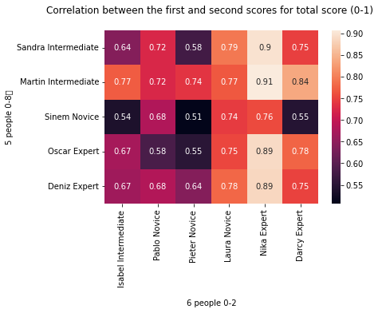

```python
import pandas as pd
import seaborn as sn
import matplotlib.pyplot as plt
import seaborn as sns


'''first_matrix_a = pd.DataFrame(df_a_new_5_people,index = None,columns = data_total_col,dtype = float)/4
second_matrix_a = pd.DataFrame(df_a_new[0:45],index = None,columns = data_total_col_new, dtype = int)


first_matrix_b = pd.DataFrame(df_b_new_5_people,index = None,columns = data_total_col,dtype = float)/4
second_matrix_b = pd.DataFrame(df_b_new[0:45],index = None,columns = data_total_col_new, dtype = int)



first_matrix_c = pd.DataFrame(df_c_new_5_people,index = None,columns = data_total_col,dtype = float)/4
second_matrix_c = pd.DataFrame(df_c_new[0:45],index = None,columns = data_total_col_new, dtype = int)


first_matrix_d = pd.DataFrame(df_d_new_5_people,index = None,columns = data_total_col,dtype = float)/4
second_matrix_d = pd.DataFrame(df_d_new[0:45],index = None,columns = data_total_col_new, dtype = int)


first_matrix_e = pd.DataFrame(df_e_new_5_people,index = None,columns = data_total_col,dtype = float)/4
second_matrix_e = pd.DataFrame(df_e_new[0:45],index = None,columns = data_total_col_new, dtype = int)
'''

'''first_matrix_f = pd.DataFrame(df_f_sorted,index = None,columns = data_total_col,dtype = int)
second_matrix_f = pd.DataFrame(df_f_new[0:45],index = None,columns = data_total_col_new, dtype = int)


first_matrix_g = pd.DataFrame(df_g_sorted,index = None,columns = data_total_col,dtype = int)
second_matrix_g = pd.DataFrame(df_g_new[0:45],index = None,columns = data_total_col_new, dtype = int)
'''

first_matrix_total = pd.DataFrame(df_total_new_5_people,index = None,columns = data_total_col,dtype = float)/56
second_matrix_total = pd.DataFrame(df_total_new[0:45],index = None,columns = data_total_col_new, dtype = float)
##################################################################################################

'''result_a = pd.concat([first_matrix_a, second_matrix_a], axis=1).corr(method='pearson')
#print(result_a)
result_b = pd.concat([first_matrix_b, second_matrix_b], axis=1).corr(method='pearson')

result_c = pd.concat([first_matrix_c, second_matrix_c], axis=1).corr(method='pearson')

result_d = pd.concat([first_matrix_d, second_matrix_d], axis=1).corr(method='pearson')

result_e = pd.concat([first_matrix_e, second_matrix_e], axis=1).corr(method='pearson')

#result_f = pd.concat([first_matrix_f, second_matrix_f], axis=1).corr(method='pearson')

#result_g = pd.concat([first_matrix_g, second_matrix_g], axis=1).corr(method='pearson')
'''
result_total = pd.concat([first_matrix_total, second_matrix_total], axis=1).corr(method='pearson')
'''
################################################################################
first_second_corr_a = result_a[['Isabel Intermediate','Pablo Novice','Pieter Novice','Laura Novice','Nika Expert','Darcy Expert']].loc[['Sandra Intermediate','Martin Intermediate','Sinem Novice','Oscar Expert','Deniz Expert']]
first_second_corr_b = result_b[['Isabel Intermediate','Pablo Novice','Pieter Novice','Laura Novice','Nika Expert','Darcy Expert']].loc[['Sandra Intermediate','Martin Intermediate','Sinem Novice','Oscar Expert','Deniz Expert']]
first_second_corr_c = result_c[['Isabel Intermediate','Pablo Novice','Pieter Novice','Laura Novice','Nika Expert','Darcy Expert']].loc[['Sandra Intermediate','Martin Intermediate','Sinem Novice','Oscar Expert','Deniz Expert']]
first_second_corr_d = result_d[['Isabel Intermediate','Pablo Novice','Pieter Novice','Laura Novice','Nika Expert','Darcy Expert']].loc[['Sandra Intermediate','Martin Intermediate','Sinem Novice','Oscar Expert','Deniz Expert']]
first_second_corr_e = result_e[['Isabel Intermediate','Pablo Novice','Pieter Novice','Laura Novice','Nika Expert','Darcy Expert']].loc[['Sandra Intermediate','Martin Intermediate','Sinem Novice','Oscar Expert','Deniz Expert']]
#first_second_corr_f = result_f[['Intermediate12','Intermediate22','Novice2','Expert12','Expert22']].loc[['Intermediate1','Intermediate2','Novice','Expert1','Expert2']]
#first_second_corr_g = result_g[['Intermediate12','Intermediate22','Novice2','Expert12','Expert22']].loc[['Intermediate1','Intermediate2','Novice','Expert1','Expert2']]

'''
first_second_corr_total = result_total[['Isabel Intermediate','Pablo Novice','Pieter Novice','Laura Novice','Nika Expert','Darcy Expert']].loc[['Sandra Intermediate','Martin Intermediate','Sinem Novice','Oscar Expert','Deniz Expert']]



'''
hm = sns.heatmap(first_second_corr_a, annot = True)
hm.set(xlabel='\nSecond round of scoring', ylabel='First round of scoring\t', title = "Correlation between the first and second scores for feature a\n")
plt.show()


hm = sns.heatmap(first_second_corr_b, annot = True)
hm.set(xlabel='\nSecond round of scoring', ylabel='First round of scoring\t', title = "Correlation between the first and second scores for feature b\n")
plt.show()

hm = sns.heatmap(first_second_corr_c, annot = True)
hm.set(xlabel='\nSecond round of scoring', ylabel='First round of scoring\t', title = "Correlation between the first and second scores for feature c\n")
plt.show()

hm = sns.heatmap(first_second_corr_d, annot = True)
hm.set(xlabel='\nSecond round of scoring', ylabel='First round of scoring\t', title = "Correlation between the first and second scores for feature d\n")
plt.show()

hm = sns.heatmap(first_second_corr_e, annot = True)
hm.set(xlabel='\nSecond round of scoring', ylabel='First round of scoring\t', title = "Correlation between the first and second scores for feature e\n")
plt.show()

hm = sns.heatmap(first_second_corr_f, annot = True)
hm.set(xlabel='\nSecond round of scoring', ylabel='First round of scoring\t', title = "Correlation between the first and second scores for feature f\n")
plt.show()

hm = sns.heatmap(first_second_corr_g, annot = True)
hm.set(xlabel='\nSecond round of scoring', ylabel='First round of scoring\t', title = "Correlation between the first and second scores for feature g\n")
plt.show()
'''

hm = sns.heatmap(first_second_corr_total, annot = True)
hm.set(xlabel='\n6 people 0-2', ylabel='5 people 0-8\t', title = "Correlation between the first and second scores for total score (0-1) \n")
plt.show()
```

## This section is the scores of Isabel, Nika, and Darcy

that they scored the same images for the second time in the range of 0-8

```python
import pandas as pd
df_third = pd.read_excel('excel_data/20211217_Scores_Histology_IA_third.xlsx',sheet_name='Repeat 0-8',na_values=None, keep_default_na=False, na_filter=True)
df_third


data_total_col_3rd =['Isabel Intermediate repeat','Nika Expert repeat','Darcy Expert repeat']
data_total_index_3rd = df_third['PDF/ EXCEL correspodent Data'][1:45]
data_total_index_3rd


data_a_3rd = df_third.iloc[1:45,[3,10,17]]
data_b_3rd = df_third.iloc[1:45,[4,11,18]]
data_c_3rd = df_third.iloc[1:45,[5,12,19]]
data_d_3rd = df_third.iloc[1:45,[6,13,20]]
data_e_3rd = df_third.iloc[1:45,[7,14,21]]
data_f_3rd = df_third.iloc[1:45,[8,15,22]]
data_g_3rd = df_third.iloc[1:45,[9,16,23]]



df_a_3rd = pd.DataFrame(data_a_3rd, columns=data_total_col_3rd)
df_a_3rd.index.name = 'Indx'

df_b_3rd = pd.DataFrame(data_b_3rd, columns=data_total_col_3rd)
df_b_3rd.index.name = 'Indx'

df_c_3rd = pd.DataFrame(data_c_3rd, columns=data_total_col_3rd)
df_c_3rd.index.name = 'Indx'

df_d_3rd = pd.DataFrame(data_d_3rd, columns=data_total_col_3rd)
df_d_3rd.index.name = 'Indx'


df_e_3rd = pd.DataFrame(data_e_3rd, columns=data_total_col_3rd)
df_e_3rd.index.name = 'Indx'

df_f_3rd = pd.DataFrame(data_f_3rd, columns=data_total_col_3rd)
df_f_3rd.index.name = 'Indx'

df_g_3rd = pd.DataFrame(data_g_3rd, columns=data_total_col_3rd)
df_g_3rd.index.name = 'Indx'



for col, i in zip(data_a_3rd,data_total_col_3rd):
  df_a_3rd.loc[:,i] = data_a_3rd[col]

for col, i in zip(data_b_3rd,data_total_col_3rd):
  df_b_3rd.loc[:,i] = data_b_3rd[col]

for col, i in zip(data_c_3rd,data_total_col_3rd):
  df_c_3rd.loc[:,i] = data_c_3rd[col]

for col, i in zip(data_d_3rd,data_total_col_3rd):
  df_d_3rd.loc[:,i] = data_d_3rd[col]

for col, i in zip(data_e_3rd,data_total_col_3rd):
  df_e_3rd.loc[:,i] = data_e_3rd[col]

for col, i in zip(data_f_3rd,data_total_col_3rd):
  df_f_3rd.loc[:,i] = data_f_3rd[col]

for col, i in zip(data_g_3rd,data_total_col_3rd):
  df_g_3rd.loc[:,i] = data_g_3rd[col]





df_total_3rd = df_a_3rd.add(df_b_3rd, fill_value=0)
df_total_3rd = df_total_3rd.add(df_c_3rd, fill_value=0)
df_total_3rd = df_total_3rd.add(df_d_3rd, fill_value=0)
df_total_3rd = df_total_3rd.add(df_e_3rd, fill_value=0)
df_total_3rd = df_total_3rd.add(df_f_3rd, fill_value=0)
df_total_3rd = df_total_3rd.add(df_g_3rd, fill_value=0)

df_total_3rd/56
```

| Indx | Isabel Intermediate repeat | Nika Expert repeat | Darcy Expert repeat |
| --- | --- | --- | --- |
| 1 | 0.767857 | 0.660714 | 0.482143 |
| 2 | 0.553571 | 0.375 | 0.303571 |
| 3 | 0.160714 | 0.053571 | 0.071429 |
| 4 | 0.285714 | 0.25 | 0.142857 |
| 5 | 0.410714 | 0.446429 | 0.214286 |
| 6 | 0.732143 | 0.714286 | 0.428571 |
| 7 | 0.821429 | 0.678571 | 0.375 |
| 8 | 0.571429 | 0.517857 | 0.303571 |
| 9 | 0.142857 | 0.071429 | 0.035714 |
| 10 | 0.089286 | 0.107143 | 0.071429 |
| 11 | 0.285714 | 0.267857 | 0.178571 |
| 12 | 0.321429 | 0.375 | 0.214286 |
| 13 | 0.125 | 0.125 | 0.142857 |
| 14 | 0.125 | 0.267857 | 0.089286 |
| 15 | 0.107143 | 0.089286 | 0.053571 |
| 16 | 0.178571 | 0.232143 | 0.089286 |
| 17 | 0.107143 | 0.285714 | 0.089286 |
| 18 | 0.285714 | 0.142857 | 0.053571 |
| 19 | 0.178571 | 0.321429 | 0.142857 |
| 20 | 0.178571 | 0.25 | 0.107143 |
| 21 | 0.785714 | 0.696429 | 0.446429 |
| 22 | 0.196429 | 0.267857 | 0.035714 |
| 23 | 0.196429 | 0.089286 | 0.125 |
| 24 | 0.357143 | 0.214286 | 0.214286 |
| 25 | 0.410714 | 0.410714 | 0.196429 |
| 26 | 0.25 | 0.125 | 0.178571 |
| 27 | 0.321429 | 0.392857 | 0.214286 |
| 28 | 0.089286 | 0.071429 | 0.017857 |
| 29 | 0.035714 | 0.035714 | 0.017857 |
| 30 | 0.785714 | 0.482143 | 0.25 |
| 31 | 0.482143 | 0.446429 | 0.214286 |
| 32 | 0.767857 | 0.553571 | 0.285714 |
| 33 | 0.642857 | 0.464286 | 0.321429 |
| 34 | 0.571429 | 0.464286 | 0.303571 |
| 35 | 0.267857 | 0.285714 | 0.107143 |
| 36 | 0.321429 | 0.196429 | 0.142857 |
| 37 | 0.678571 | 0.428571 | 0.25 |
| 38 | 0.410714 | 0.357143 | 0.196429 |
| 39 | 0.642857 | 0.589286 | 0.321429 |
| 40 | 0.821429 | 0.625 | 0.339286 |
| 41 | 0.125 | 0.107143 | 0.017857 |
| 42 | 0.053571 | 0.0 | 0.0 |
| 43 | 0.410714 | 0.392857 | 0.196429 |
| 44 | 0.017857 | 0.089286 | 0.0 |

### The following section is the correlation (agreement) of the 6 people scores with the three of them for the total score.

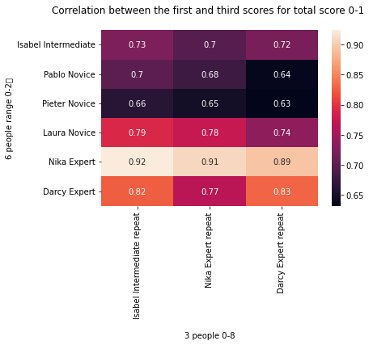

```python
import pandas as pd
import seaborn as sn
import matplotlib.pyplot as plt
import seaborn as sns

'''
first_matrix_a = pd.DataFrame(df_e_new[0:45],index = None,columns = data_total_col_new,dtype = float)
second_matrix_a = pd.DataFrame(df_a_3rd[0:45],index = None,columns = data_total_col_3rd, dtype = float)/4


first_matrix_b = pd.DataFrame(df_b_new[0:45],index = None,columns = data_total_col_new,dtype = float)
second_matrix_b = pd.DataFrame(df_b_3rd[0:45],index = None,columns = data_total_col_3rd, dtype = float)/4



first_matrix_c = pd.DataFrame(df_c_new[0:45],index = None,columns = data_total_col_new,dtype = float)
second_matrix_c = pd.DataFrame(df_c_3rd[0:45],index = None,columns = data_total_col_3rd, dtype = float)/4


first_matrix_d = pd.DataFrame(df_d_new[0:45],index = None,columns = data_total_col_new,dtype = float)
second_matrix_d = pd.DataFrame(df_d_3rd[0:45],index = None,columns = data_total_col_3rd, dtype = float)/4


first_matrix_e = pd.DataFrame(df_e_new[0:45],index = None,columns = data_total_col_new,dtype = float)
second_matrix_e = pd.DataFrame(df_e_3rd[0:45],index = None,columns = data_total_col_3rd, dtype = float)/4
'''


first_matrix_total = pd.DataFrame(df_total_new[0:45],index = None,columns = data_total_col_new,dtype = float)
second_matrix_total = pd.DataFrame(df_total_3rd[0:45],index = None,columns = data_total_col_3rd, dtype = float)
##################################################################################################
'''
result_a = pd.concat([first_matrix_a, second_matrix_a], axis=1).corr(method='pearson')
#print(result_a)
result_b = pd.concat([first_matrix_b, second_matrix_b], axis=1).corr(method='pearson')

result_c = pd.concat([first_matrix_c, second_matrix_c], axis=1).corr(method='pearson')

result_d = pd.concat([first_matrix_d, second_matrix_d], axis=1).corr(method='pearson')

result_e = pd.concat([first_matrix_e, second_matrix_e], axis=1).corr(method='pearson')

'''
result_total = pd.concat([first_matrix_total, second_matrix_total], axis=1).corr(method='pearson')
'''
################################################################################
first_second_corr_a = result_a[['Isabel Intermediate repeat','Nika Expert repeat','Darcy Expert repeat']].loc[['Isabel Intermediate','Pablo Novice','Pieter Novice','Laura Novice','Nika Expert','Darcy Expert']]
first_second_corr_b = result_b[['Isabel Intermediate repeat','Nika Expert repeat','Darcy Expert repeat']].loc[['Isabel Intermediate','Pablo Novice','Pieter Novice','Laura Novice','Nika Expert','Darcy Expert']]
first_second_corr_c = result_c[['Isabel Intermediate repeat','Nika Expert repeat','Darcy Expert repeat']].loc[['Isabel Intermediate','Pablo Novice','Pieter Novice','Laura Novice','Nika Expert','Darcy Expert']]
first_second_corr_d = result_d[['Isabel Intermediate repeat','Nika Expert repeat','Darcy Expert repeat']].loc[['Isabel Intermediate','Pablo Novice','Pieter Novice','Laura Novice','Nika Expert','Darcy Expert']]
first_second_corr_e = result_e[['Isabel Intermediate repeat','Nika Expert repeat','Darcy Expert repeat']].loc[['Isabel Intermediate','Pablo Novice','Pieter Novice','Laura Novice','Nika Expert','Darcy Expert']]
'''
first_second_corr_total = result_total[['Isabel Intermediate repeat','Nika Expert repeat','Darcy Expert repeat']].loc[['Isabel Intermediate','Pablo Novice','Pieter Novice','Laura Novice','Nika Expert','Darcy Expert']]


'''

hm = sns.heatmap(first_second_corr_a, annot = True)
hm.set(xlabel='\nThird round of scoring', ylabel='First round of scoring\t', title = "Correlation between the first and third scores for feature a\n")
plt.show()


hm = sns.heatmap(first_second_corr_b, annot = True)
hm.set(xlabel='\nThird round of scoring', ylabel='First round of scoring\t', title = "Correlation between the first and third scores for feature b\n")
plt.show()

hm = sns.heatmap(first_second_corr_c, annot = True)
hm.set(xlabel='\nThird round of scoring', ylabel='First round of scoring\t', title = "Correlation between the first and third scores for feature c\n")
plt.show()

hm = sns.heatmap(first_second_corr_d, annot = True)
hm.set(xlabel='\nThird round of scoring', ylabel='First round of scoring\t', title = "Correlation between the first and third scores for feature d\n")
plt.show()

hm = sns.heatmap(first_second_corr_e, annot = True)
hm.set(xlabel='\nThird round of scoring', ylabel='First round of scoring\t', title = "Correlation between the first and third scores for feature e\n")
plt.show()

'''

hm = sns.heatmap(first_second_corr_total, annot = True)
hm.set(xlabel='\n3 people 0-8', ylabel='6 people range 0-2\t', title = "Correlation between the first and third scores for total score 0-1 \n")
plt.show()
#print(result_a[['Intermediate12','Intermediate22','Novice2','Expert12','Expert22']].loc[['Intermediate1','Intermediate2','Novice','Expert1','Expert2']])
#print(result[['Intermediate1','Intermediate2','Novice','Expert1','Expert2']].loc[['Intermediate12','Intermediate22','Novice2','Expert12','Expert22']])
```

### The following section is the correlation (agreement) of the 5 people and three people vs 6 people for total score.

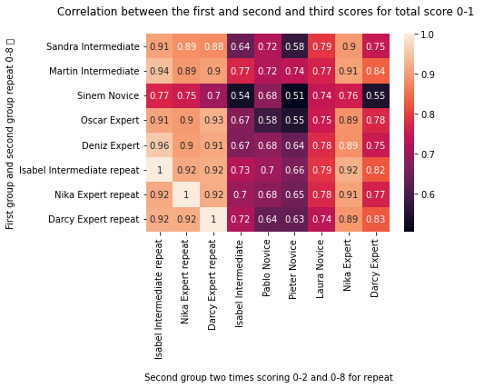

```python
import pandas as pd
import seaborn as sn
import matplotlib.pyplot as plt
import seaborn as sns

'''
first_matrix_a = pd.DataFrame(df_a_new_5_people,index = None,columns = data_total_col,dtype = float)/4
second_matrix_a = pd.DataFrame(df_a_new,index = None,columns = data_total_col_new,dtype = float)
third_matrix_a = pd.DataFrame(df_a_3rd[0:45],index = None,columns = data_total_col_3rd, dtype = float)/4


first_matrix_b = pd.DataFrame(df_b_new_5_people,index = None,columns = data_total_col,dtype = float)/4
second_matrix_b = pd.DataFrame(df_b_new,index = None,columns = data_total_col_new,dtype = float)
third_matrix_b = pd.DataFrame(df_b_3rd[0:45],index = None,columns = data_total_col_3rd, dtype = float)/4



first_matrix_c = pd.DataFrame(df_c_new_5_people,index = None,columns = data_total_col,dtype = float)/4
second_matrix_c = pd.DataFrame(df_c_new,index = None,columns = data_total_col_new,dtype = float)
third_matrix_c = pd.DataFrame(df_c_3rd[0:45],index = None,columns = data_total_col_3rd, dtype = float)/4


first_matrix_d = pd.DataFrame(df_d_new_5_people,index = None,columns = data_total_col,dtype = float)/4
second_matrix_d = pd.DataFrame(df_d_new,index = None,columns = data_total_col_new,dtype = float)
third_matrix_d = pd.DataFrame(df_d_3rd[0:45],index = None,columns = data_total_col_3rd, dtype = float)/4


first_matrix_e = pd.DataFrame(df_e_new_5_people,index = None,columns = data_total_col,dtype = float)/4
second_matrix_e = pd.DataFrame(df_e_new,index = None,columns = data_total_col_new,dtype = float)
third_matrix_e = pd.DataFrame(df_e_3rd[0:45],index = None,columns = data_total_col_3rd, dtype = float)/4

 '''


first_matrix_total = pd.DataFrame(df_total_new_5_people,index = None,columns = data_total_col,dtype = float)/4
second_matrix_total = pd.DataFrame(df_total_new,index = None,columns = data_total_col_new,dtype = float)
third_matrix_total = pd.DataFrame(df_total_3rd[0:45],index = None,columns = data_total_col_3rd, dtype = float)/4
##################################################################################################
'''
result_a = pd.concat([first_matrix_a, second_matrix_a, third_matrix_a], axis=1).corr(method='pearson')
#print(result_a)
result_b = pd.concat([first_matrix_b, second_matrix_b, third_matrix_b], axis=1).corr(method='pearson')

result_c = pd.concat([first_matrix_c, second_matrix_c, third_matrix_c], axis=1).corr(method='pearson')

result_d = pd.concat([first_matrix_d, second_matrix_d, third_matrix_d], axis=1).corr(method='pearson')

result_e = pd.concat([first_matrix_e, second_matrix_e, third_matrix_e], axis=1).corr(method='pearson')
'''

result_total = pd.concat([first_matrix_total, second_matrix_total, third_matrix_total], axis=1).corr(method='pearson')

################################################################################
'''
first_second_third_corr_a = result_a[['Isabel Intermediate repeat','Nika Expert repeat','Darcy Expert repeat','Isabel Intermediate','Pablo Novice','Pieter Novice','Laura Novice','Nika Expert','Darcy Expert']].loc[['Sandra Intermediate','Martin Intermediate','Sinem Novice','Oscar Expert','Deniz Expert','Isabel Intermediate repeat','Nika Expert repeat','Darcy Expert repeat']]
first_second_third_corr_b = result_b[['Isabel Intermediate repeat','Nika Expert repeat','Darcy Expert repeat','Isabel Intermediate','Pablo Novice','Pieter Novice','Laura Novice','Nika Expert','Darcy Expert']].loc[['Sandra Intermediate','Martin Intermediate','Sinem Novice','Oscar Expert','Deniz Expert','Isabel Intermediate repeat','Nika Expert repeat','Darcy Expert repeat']]
first_second_third_corr_c = result_c[['Isabel Intermediate repeat','Nika Expert repeat','Darcy Expert repeat','Isabel Intermediate','Pablo Novice','Pieter Novice','Laura Novice','Nika Expert','Darcy Expert']].loc[['Sandra Intermediate','Martin Intermediate','Sinem Novice','Oscar Expert','Deniz Expert','Isabel Intermediate repeat','Nika Expert repeat','Darcy Expert repeat']]
first_second_third_corr_d = result_d[['Isabel Intermediate repeat','Nika Expert repeat','Darcy Expert repeat','Isabel Intermediate','Pablo Novice','Pieter Novice','Laura Novice','Nika Expert','Darcy Expert']].loc[['Sandra Intermediate','Martin Intermediate','Sinem Novice','Oscar Expert','Deniz Expert','Isabel Intermediate repeat','Nika Expert repeat','Darcy Expert repeat']]
first_second_third_corr_e = result_e[['Isabel Intermediate repeat','Nika Expert repeat','Darcy Expert repeat','Isabel Intermediate','Pablo Novice','Pieter Novice','Laura Novice','Nika Expert','Darcy Expert']].loc[['Sandra Intermediate','Martin Intermediate','Sinem Novice','Oscar Expert','Deniz Expert','Isabel Intermediate repeat','Nika Expert repeat','Darcy Expert repeat']]
'''

first_second_third_corr_total = result_total[['Isabel Intermediate repeat','Nika Expert repeat','Darcy Expert repeat','Isabel Intermediate','Pablo Novice','Pieter Novice','Laura Novice','Nika Expert','Darcy Expert']].loc[['Sandra Intermediate','Martin Intermediate','Sinem Novice','Oscar Expert','Deniz Expert','Isabel Intermediate repeat','Nika Expert repeat','Darcy Expert repeat']]


'''

hm = sns.heatmap(first_second_third_corr_a, annot = True)
hm.set(xlabel='\n Second group two times scoring', ylabel='First group and second group repeat\t', title = "Correlation between the first and second and third scores for feature a\n")
plt.show()


hm = sns.heatmap(first_second_third_corr_b, annot = True)
hm.set(xlabel='\n Second group two times scoring', ylabel='First group and second group repeat\t', title = "Correlation between the first and second and third scores for feature b\n")
plt.show()

hm = sns.heatmap(first_second_third_corr_c, annot = True)
hm.set(xlabel='\n Second group two times scoring', ylabel='First group and second group repeat\t', title = "Correlation between the first and second and third scores for feature c\n")
plt.show()

hm = sns.heatmap(first_second_third_corr_d, annot = True)
hm.set(xlabel='\n Second group two times scoring', ylabel='First group and second group repeat\t', title = "Correlation between the first and second and third scores for feature d\n")
plt.show()

hm = sns.heatmap(first_second_third_corr_e, annot = True)
hm.set(xlabel='\n Second group two times scoring', ylabel='First group and second group repeat\t', title = "Correlation between the first and second and third scores for feature e\n")
plt.show()
'''

hm = sns.heatmap(first_second_third_corr_total, annot = True)
hm.set(xlabel='\n Second group two times scoring 0-2 and 0-8 for repeat', ylabel='First group and second group repeat 0-8 \t', title = "Correlation between the first and second and third scores for total score 0-1 \n")
plt.show()
```

### The following section is the correlation (agreement) of the 5 people and three people vs 6 people for over all sample groups and for each sample group separately.

```
[13, 14, 15, 16, 17, 18, 19, 21, 40, 41]
[2, 9, 12, 22, 28]
[29, 30, 35, 36, 37, 38, 39]
[0, 1, 3, 4, 5, 6, 7, 20, 31, 32, 42]
[10, 11, 23, 24, 25, 26, 27, 33, 34, 43]
```

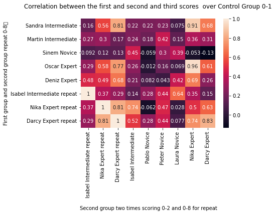

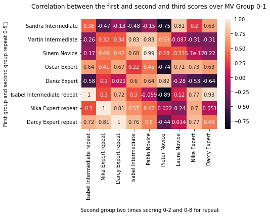

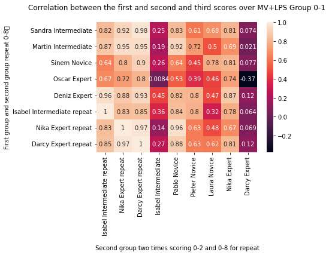

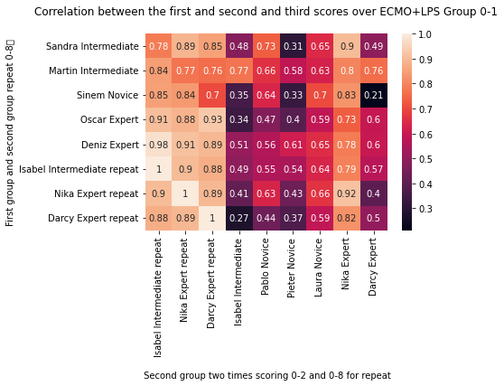

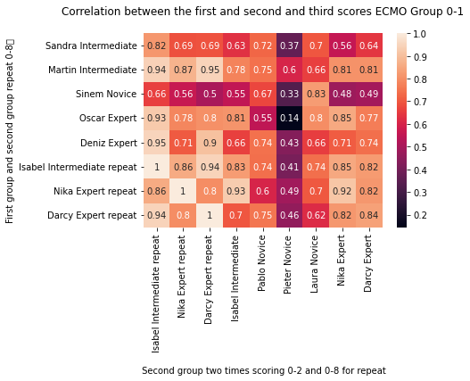

```python
import pandas as pd
df_third_ = pd.read_excel('excel_data/20211217_Scores_Histology_IA_third.xlsx',sheet_name='Repeat 0-8',na_values=None, keep_default_na=False, na_filter=True)
df_third = df_third_[0:46]

index = df_third.index
Control_index = df_third['Unnamed: 2']=='Control'
Control_condition = index[Control_index]-1
Control_list  = Control_condition.tolist()

print(Control_list)

MV_index = df_third['Unnamed: 2']=='MV'
MV_condition = index[MV_index]-1
MV_list  = MV_condition.tolist()

print(MV_list)

MV_LPS_index = df_third['Unnamed: 2']=='MV+LPS'
MV_LPS_condition = index[MV_LPS_index]-1
MV_LPS_list  = MV_LPS_condition.tolist()

print(MV_LPS_list)

ECMO_LPS_index = df_third['Unnamed: 2']=='ECMO + LPS'
ECMO_LPS_condition = index[ECMO_LPS_index]-1
ECMO_LPS_list  = ECMO_LPS_condition.tolist()

print(ECMO_LPS_list)

ECMO_index = df_third['Unnamed: 2']=='ECMO'
ECMO_condition = index[ECMO_index]-1
ECMO_list  = ECMO_condition.tolist()
print(ECMO_list)



##Control

first_matrix_total_Control = pd.DataFrame(df_total_new_5_people.iloc[Control_list],index = None,columns = data_total_col,dtype = float)/4
second_matrix_total_Control = pd.DataFrame(df_total_new.iloc[Control_list],index = None,columns = data_total_col_new,dtype = float)
third_matrix_total_Control = pd.DataFrame(df_total_3rd.iloc[Control_list],index = None,columns = data_total_col_3rd, dtype = float)/4



result_Control = pd.concat([first_matrix_total_Control, second_matrix_total_Control, third_matrix_total_Control], axis=1).corr(method='pearson')
first_second_third_corr_total_Control = result_Control[['Isabel Intermediate repeat','Nika Expert repeat','Darcy Expert repeat','Isabel Intermediate','Pablo Novice','Pieter Novice','Laura Novice','Nika Expert','Darcy Expert']].loc[['Sandra Intermediate','Martin Intermediate','Sinem Novice','Oscar Expert','Deniz Expert','Isabel Intermediate repeat','Nika Expert repeat','Darcy Expert repeat']]
hm = sns.heatmap(first_second_third_corr_total_Control, annot = True)
hm.set(xlabel='\n Second group two times scoring 0-2 and 0-8 for repeat', ylabel='First group and second group repeat 0-8\t', title = "Correlation between the first and second and third scores  over Control Group 0-1\n")
plt.show()




###MV
first_matrix_total_MV = pd.DataFrame(df_total_new_5_people.iloc[MV_list],index = None,columns = data_total_col,dtype = float)/4
second_matrix_total_MV = pd.DataFrame(df_total_new.iloc[MV_list],index = None,columns = data_total_col_new,dtype = float)
third_matrix_total_MV = pd.DataFrame(df_total_3rd.iloc[MV_list],index = None,columns = data_total_col_3rd, dtype = float)/4

result_MV = pd.concat([first_matrix_total_MV, second_matrix_total_MV, third_matrix_total_MV], axis=1).corr(method='pearson')
first_second_third_corr_total_MV = result_MV[['Isabel Intermediate repeat','Nika Expert repeat','Darcy Expert repeat','Isabel Intermediate','Pablo Novice','Pieter Novice','Laura Novice','Nika Expert','Darcy Expert']].loc[['Sandra Intermediate','Martin Intermediate','Sinem Novice','Oscar Expert','Deniz Expert','Isabel Intermediate repeat','Nika Expert repeat','Darcy Expert repeat']]
hm = sns.heatmap(first_second_third_corr_total_MV, annot = True)
hm.set(xlabel='\n Second group two times scoring 0-2 and 0-8 for repeat', ylabel='First group and second group repeat 0-8\t', title = "Correlation between the first and second and third scores over MV Group 0-1\n")
plt.show()



###MV
first_matrix_total_MV_LPS = pd.DataFrame(df_total_new_5_people.iloc[MV_LPS_list],index = None,columns = data_total_col,dtype = float)/4
second_matrix_total_MV_LPS = pd.DataFrame(df_total_new.iloc[MV_LPS_list],index = None,columns = data_total_col_new,dtype = float)
third_matrix_total_MV_LPS = pd.DataFrame(df_total_3rd.iloc[MV_LPS_list],index = None,columns = data_total_col_3rd, dtype = float)/4

result_MV_LPS = pd.concat([first_matrix_total_MV_LPS, second_matrix_total_MV_LPS, third_matrix_total_MV_LPS], axis=1).corr(method='pearson')
first_second_third_corr_total_MV_LPS = result_MV_LPS[['Isabel Intermediate repeat','Nika Expert repeat','Darcy Expert repeat','Isabel Intermediate','Pablo Novice','Pieter Novice','Laura Novice','Nika Expert','Darcy Expert']].loc[['Sandra Intermediate','Martin Intermediate','Sinem Novice','Oscar Expert','Deniz Expert','Isabel Intermediate repeat','Nika Expert repeat','Darcy Expert repeat']]
hm = sns.heatmap(first_second_third_corr_total_MV_LPS, annot = True)
hm.set(xlabel='\n Second group two times scoring 0-2 and 0-8 for repeat', ylabel='First group and second group repeat 0-8\t', title = "Correlation between the first and second and third scores over MV+LPS Group 0-1\n")
plt.show()

###ECMO+LPS
first_matrix_total_ECMO_LPS = pd.DataFrame(df_total_new_5_people.iloc[ECMO_LPS_list],index = None,columns = data_total_col,dtype = float)/4
second_matrix_total_ECMO_LPS = pd.DataFrame(df_total_new.iloc[ECMO_LPS_list],index = None,columns = data_total_col_new,dtype = float)
third_matrix_total_ECMO_LPS = pd.DataFrame(df_total_3rd.iloc[ECMO_LPS_list],index = None,columns = data_total_col_3rd, dtype = float)/4

result_ECMO_LPS = pd.concat([first_matrix_total_ECMO_LPS, second_matrix_total_ECMO_LPS, third_matrix_total_ECMO_LPS], axis=1).corr(method='pearson')
first_second_third_corr_total_ECMO_LPS = result_ECMO_LPS[['Isabel Intermediate repeat','Nika Expert repeat','Darcy Expert repeat','Isabel Intermediate','Pablo Novice','Pieter Novice','Laura Novice','Nika Expert','Darcy Expert']].loc[['Sandra Intermediate','Martin Intermediate','Sinem Novice','Oscar Expert','Deniz Expert','Isabel Intermediate repeat','Nika Expert repeat','Darcy Expert repeat']]
hm = sns.heatmap(first_second_third_corr_total_ECMO_LPS, annot = True)
hm.set(xlabel='\n Second group two times scoring 0-2 and 0-8 for repeat', ylabel='First group and second group repeat 0-8\t', title = "Correlation between the first and second and third scores over ECMO+LPS Group 0-1\n")
plt.show()


###ECMO
first_matrix_total_ECMO = pd.DataFrame(df_total_new_5_people.iloc[ECMO_list],index = None,columns = data_total_col,dtype = float)/4
second_matrix_total_ECMO = pd.DataFrame(df_total_new.iloc[ECMO_list],index = None,columns = data_total_col_new,dtype = float)
third_matrix_total_ECMO = pd.DataFrame(df_total_3rd.iloc[ECMO_list],index = None,columns = data_total_col_3rd, dtype = float)/4

result_ECMO = pd.concat([first_matrix_total_ECMO, second_matrix_total_ECMO, third_matrix_total_ECMO], axis=1).corr(method='pearson')
first_second_third_corr_total_ECMO = result_ECMO[['Isabel Intermediate repeat','Nika Expert repeat','Darcy Expert repeat','Isabel Intermediate','Pablo Novice','Pieter Novice','Laura Novice','Nika Expert','Darcy Expert']].loc[['Sandra Intermediate','Martin Intermediate','Sinem Novice','Oscar Expert','Deniz Expert','Isabel Intermediate repeat','Nika Expert repeat','Darcy Expert repeat']]
hm = sns.heatmap(first_second_third_corr_total_ECMO, annot = True)
hm.set(xlabel='\n Second group two times scoring 0-2 and 0-8 for repeat', ylabel='First group and second group repeat 0-8\t', title = "Correlation between the first and second and third scores ECMO Group 0-1\n")
plt.show()
```